# 4.Archivos

2/3/2021

## Flujo de trabajo

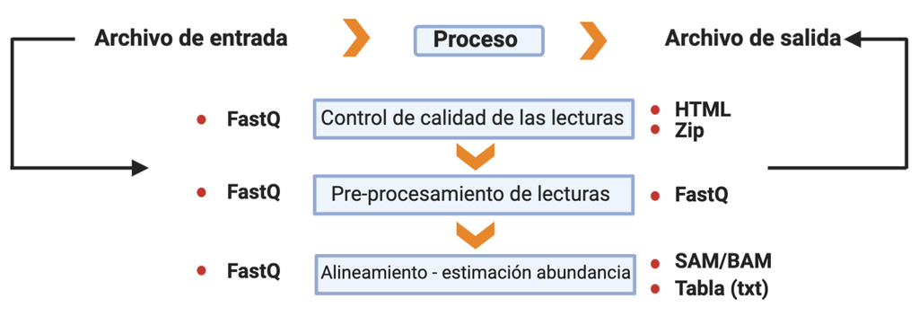

## FastQ

- Derivado del formato FASTA
- FASTA + Id secuencia + **Calidad**
- Generalmente no está comprimido (.fastq) > comprimir (.fastq.gz)
- Comprende 4 líneas por secuencia:
  - @ ID del read + información de la corrida
  - Secuencia
  - Símbolo “+”
  - Calidad (Escala **Phred** y código **ASCII**)

## FastQ

- El identificador de la secuencia es la primera línea del archivo .fastq
- Plataformas de Illumina superiores a 1.8 contienen la siguiente información:

**@machneID:run number:flowCell ID:lane:tile:read:control number:index**

```
## @SRR12038075.1 D00635:426:CD19YANXX:5:2301:1410:2130/1
```

## FastQ

La calidad de cada base secuenciada, en la escala **Phred**, se calcula de acuerdo la siguiente ecuación:

**Q = -10 * log10(p)**

Q = Calidad

p = Probabilidad de que el base call sea incorrecto

Valores de **p** cercanos a cero -> Alta calidad

¿Cuál es la calidad si el valor p del basecall es de 0.01?

## FastQ

- Para evitar colocar los valores numéricos de la calidad en el archivo .fastq y saturarlo de información -> **ASCII**
- El código ASCII lo pueden consultar [aquí](https://www.ascii-code.com/)
- Phred + 33 -> Plataformas de Illumina a partir de 1.8 (símbolos especiales + alfanuméricos)
- Phred - 64 -> Plataformas de Illumina anteriores a 1.8

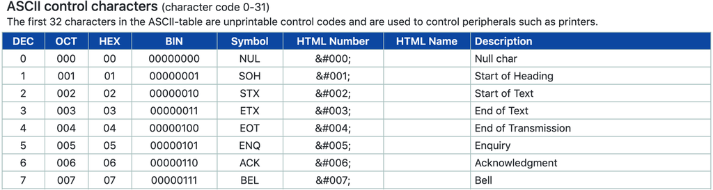

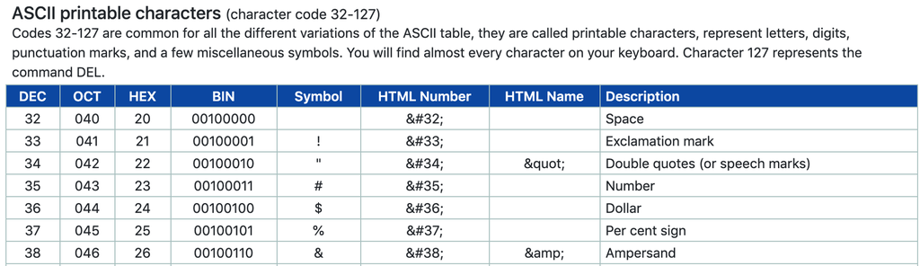

## FastQ

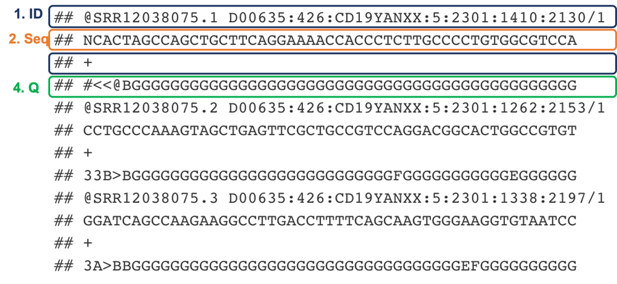